# Lab5.1_BA

Berent Aldikacti

9/27/2020

### Load packages

```r
library("tidyverse")
```

### Load data

```r
surveys_complete <- read_csv("data/surveys_complete.csv")
```

### Challenge (Optional)

Examine the strenghts and weaknesses of hexbin plotting

```r
library("hexbin")
surveys_plot <- ggplot(data = surveys_complete,
                       mapping = aes(x = weight, y = hindfoot_length))
```

Hexbin is useful when we want to show the density of data points in a densely populated plot

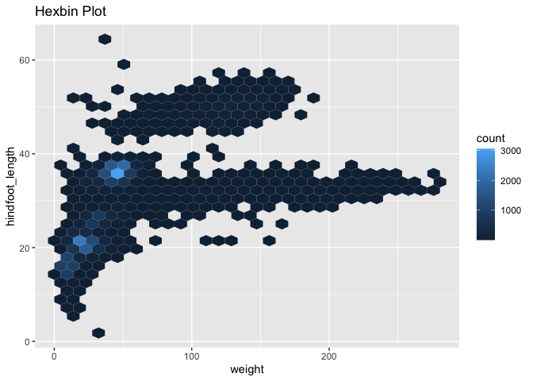

```r
surveys_plot +
 geom_hex() +
  ggtitle("Hexbin Plot")
```

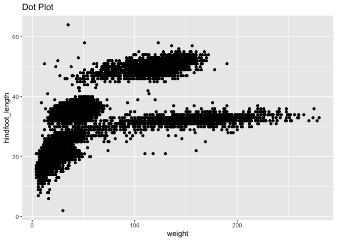

```r
surveys_plot +
 geom_point() +
  ggtitle("Dot Plot")
```

## Challenge

Use what you just learned to create a scatter plot of *weight* over *species_id* with the plot types showing in different colors. Is this a good way to show this type of data?

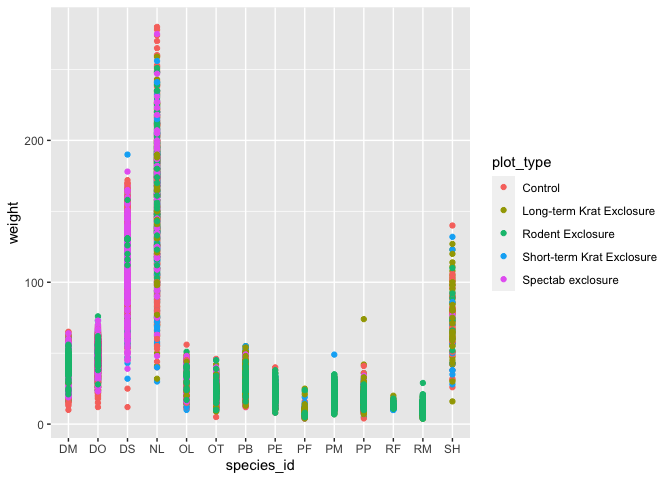

```r
ggplot(data = surveys_complete, mapping = aes(x = species_id, y = weight, color=plot_type)) +
    geom_point()
```

*Answer:* This is not a good way to show this data because it is hard to see if there are any patterns to weight among plot_type.

## Challenges

1. Replace the box plot with a violin plot; see geom_violin().

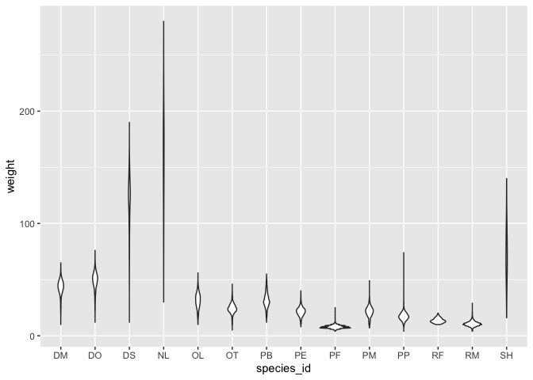

```r
ggplot(data = surveys_complete, mapping = aes(x = species_id, y = weight)) +
    geom_violin()
```

2. Represent weight on the log10 scale; see scale_y_log10().

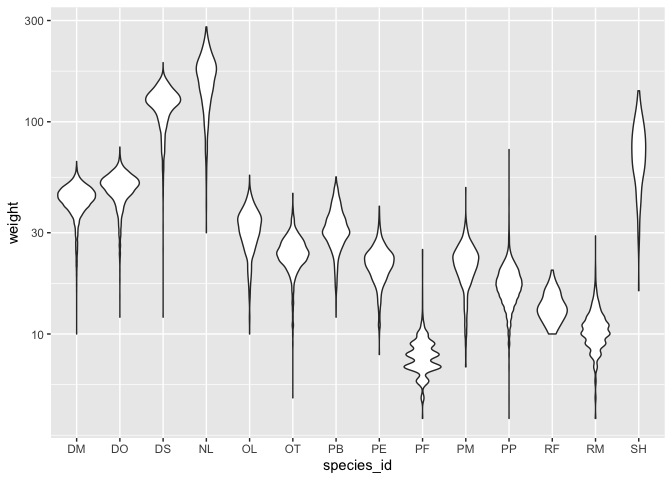

```r
ggplot(data = surveys_complete, mapping = aes(x = species_id, y = weight)) +
  geom_violin() +
  scale_y_log10()
```

3. Create boxplot for hindfoot_length. Overlay the boxplot layer on a jitter layer to show actual measurements.

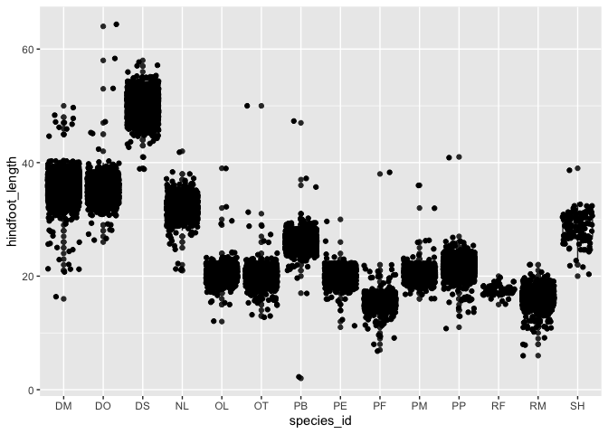

```r
ggplot(data = surveys_complete, mapping = aes(x = species_id, y = hindfoot_length)) +
   geom_boxplot() +
   geom_jitter()
```

4. Add color to the data points on your boxplot according to the plot from which the sample was taken (plot_id).

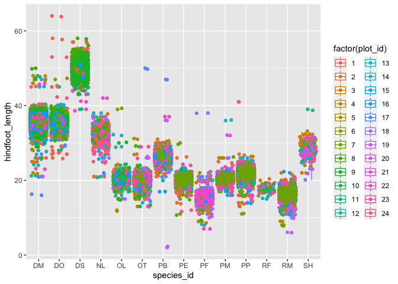

```r
ggplot(data = surveys_complete, mapping = aes(x = species_id, y = hindfoot_length, color=factor(plot_id))) +
   geom_boxplot() +
   geom_jitter()
```

## Challenge

Use what you just learned to create a plot that depicts how the *average weight* of each *species* changes through the *years*.

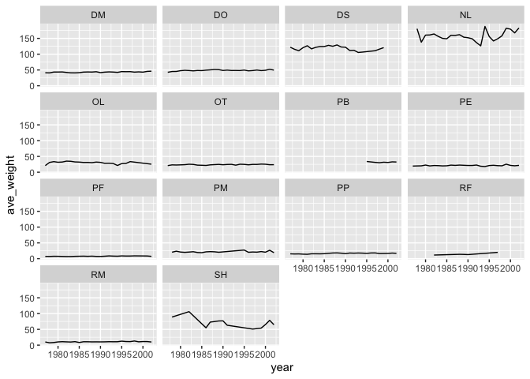

```r
surveys_complete %>% group_by(species_id,year) %>% summarize(ave_weight=mean(weight)) %>%
  ggplot(aes(x=year,y=ave_weight)) +
  geom_line() +
  facet_wrap(vars(species_id))
```

## Challenge

With all of this information in hand, please take another five minutes to either improve one of the plots generated in this exercise or create a beautiful graph of your own. Use the RStudio ggplot2 cheat sheet for inspiration.

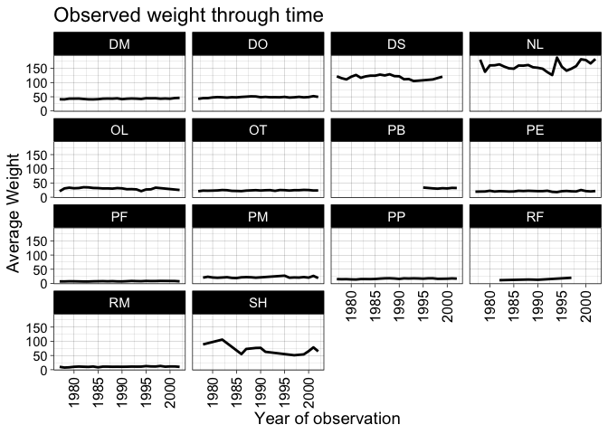

```r
surveys_complete %>% group_by(species_id,year) %>% summarize(ave_weight=mean(weight)) %>%
  ggplot(aes(x=year,y=ave_weight)) +
  geom_line(size=1) +
  facet_wrap(vars(species_id)) +
  theme_linedraw() +
  labs(title = "Observed weight through time",
        x = "Year of observation",
        y = "Average Weight") +
  theme(axis.text.x = element_text(size = 12,
                                   angle = 90, hjust = 0.5,
                                   vjust = 0.5),
                    axis.text.y = element_text(size = 11),
                    text=element_text(size = 14))
```